```r
#install.packages("arrow")
library(arrow)
```

```r
#install.packages("ggplot2")
library(ggplot2)

library(dplyr) # to use the %>% operator
parquet_data <- read_parquet("combined_data_parquet_file_onemin_Ground_2015.parquet")
```

```r
df = parquet_data
column_names <- colnames(df)
print(column_names)
```

```
##   [1] "TIMESTAMP"             "Pyra1_Wm2_Avg"         "Pyra2_Wm2_Avg"
##   [4] "RECORD"                "CR1000Temp_C_Avg"      "DoorOpen_Min"
##   [7] "RefCell1_Wm2_Avg"      "AmbTemp_C_Avg"         "InvVDVoltage_V_Avg"
##  [10] "InvVa_Avg"             "InvVb_Avg"             "InvVc_Avg"
##  [13] "InvIa_Avg"             "InvIb_Avg"             "InvIc_Avg"
##  [16] "InvVDCin_Avg"          "InvIDCin_Avg"          "InvFreq_Avg"
##  [19] "InvPAC_kW_Avg"         "InvEtot_kWh_Max"       "InvVPVin_Avg"
##  [22] "InvPDC_kW_Avg"         "InvOpStatus_Avg"       "InvMainFault_Max"
##  [25] "InvDriveFault_Max"     "InvVoltageFault_Max"   "InvGridFault_Max"
##  [28] "InvTempFault_Max"      "InvSystemFault_Max"    "InvSystemWarn_Max"
##  [31] "InvPVMStatus_Max"      "SEWSAmbientTemp_C_Avg" "SEWSModuleTemp_C_Avg"
##  [34] "SEWSPOAIrrad_Wm2_Avg"  "PwrMtrIa_Avg"          "PwrMtrIb_Avg"
##  [37] "PwrMtrIc_Avg"          "PwrMtrFreq_Avg"        "PwrMtrFreqMin_Min"
##  [40] "PwrMtrFreqMax_Max"     "PwrMtrPhaseRev_Avg"    "PwrMtrVa_Avg"
##  [43] "PwrMtrVb_Avg"          "PwrMtrVc_Avg"          "PwrMtrP_kW_Avg"
```

[output cut: 19 more lines]

1. Et pyranometer måler innstrålingen av sol som et gitt antall Watt pr. kvadratmeter. Velg en tilfeldig uke på sommeren 2015, og plott tidsstempel på X-aksen, og verdien til “Pyra1_Wm2_Avg” på Y-aksen.

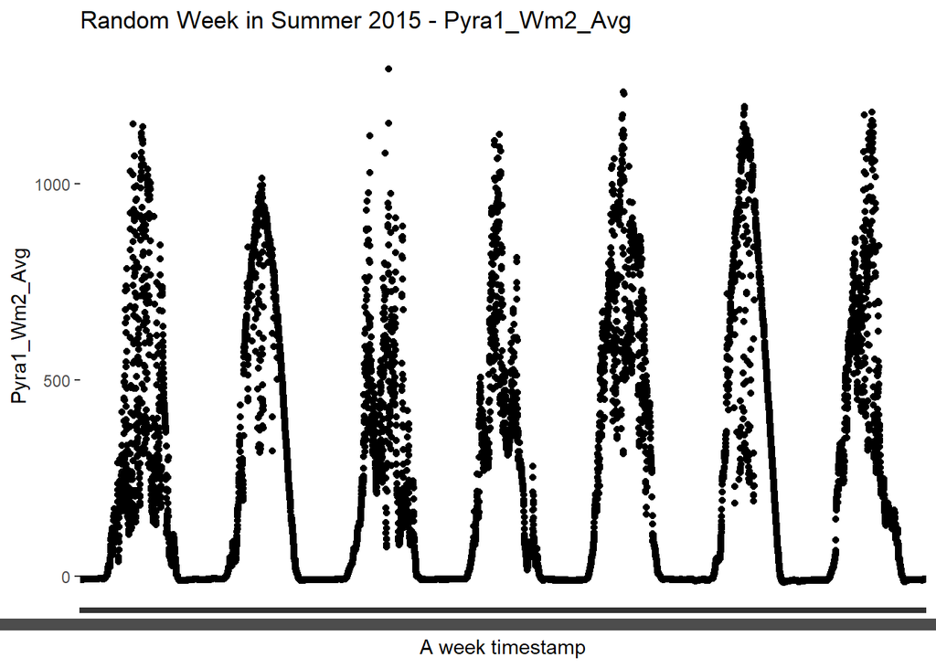

```r
# Filter the data for the specified date range
random_week_df <- df[df$TIMESTAMP >= as.Date("2015-07-06") & df$TIMESTAMP <= as.Date("2015-07-12"), ]

# Create a scatter plot using ggplot2
ggplot(random_week_df, aes(x = TIMESTAMP, y = Pyra1_Wm2_Avg)) +
  geom_point() +
  labs(x = "A week timestamp", y = "Pyra1_Wm2_Avg") +
  ggtitle("Random Week in Summer 2015 - Pyra1_Wm2_Avg")
```

2. “InvPDC_kW_Avg” er gjennomsnittlig effekt produsert av solcelleanlegget pr. minutt. Legg til denne verdien på Y-aksen.

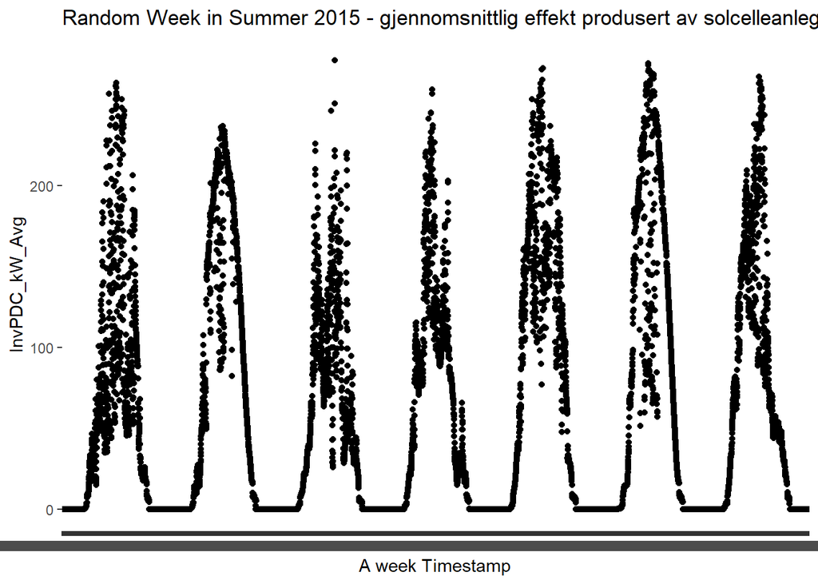

```r
ggplot(random_week_df, aes(x = TIMESTAMP, y = InvPDC_kW_Avg)) +
  geom_point() +
  labs(x = "A week Timestamp", y = "InvPDC_kW_Avg") +
  ggtitle("Random Week in Summer 2015 - gjennomsnittlig effekt produsert av solcelleanlegget pr. minutt")
```

3. Er “Pyra1_Wm2_Avg” og “InvPDC_kW_Avg” avhengige eller uavhengige variabler? Beregn Pearson Correlation mellom de to variablene. Begrunn svaret ditt. Hva tenker du om årsak og virkning?

```r
# To fix the "Pearson Correlation: NA" result, we need to remove rows with missing values  in either column
# As suggested by the lecturer, we need to filter the negative values from the datasett

df_clean <- na.omit(df[c("Pyra1_Wm2_Avg", "InvPDC_kW_Avg")]) %>%
  filter(Pyra1_Wm2_Avg >=0.0,InvPDC_kW_Avg >=0.0 )
```

```r
# Calculate Pearson correlation
correlation <- cor(df_clean$Pyra1_Wm2_Avg, df_clean$InvPDC_kW_Avg)

correlation2 <- cor(df_clean$InvPDC_kW_Avg, df_clean$Pyra1_Wm2_Avg)

# round the result for five digits after the decimal point
formatted_correlation <- sprintf("%.5f", correlation)
formatted_correlation2 <- sprintf("%.5f", correlation2)

# Print the correlation coefficient
print(paste("Pearson Correlation between “Pyra1_Wm2_Avg” and “InvPDC_kW_Avg”:", formatted_correlation))
```

```
## [1] "Pearson Correlation between “Pyra1_Wm2_Avg” and “InvPDC_kW_Avg”: 0.90683"
```

```r
print(paste("Pearson Correlation between “InvPDC_kW_Avg” and “Pyra1_Wm2_Avg”:", formatted_correlation2))
```

```
## [1] "Pearson Correlation between “InvPDC_kW_Avg” and “Pyra1_Wm2_Avg”: 0.90683"
```

Answer C: The Pearson Correlation between “Pyra1_Wm2_Avg” and “InvPDC_kW_Avg” variables is high “91%”. There is linear relationship between them, thus there is causation. We can conclude that there is “correlation”. Every variable is dependent variable which means that any change in one variable affects the secound one.

4. Plott sammenhengen mellom de to variablene (scatterplot), med “InvPDC_kW_Avg” på X-aksen, “Pyra1_Wm2_Avg” på Y-aksen.

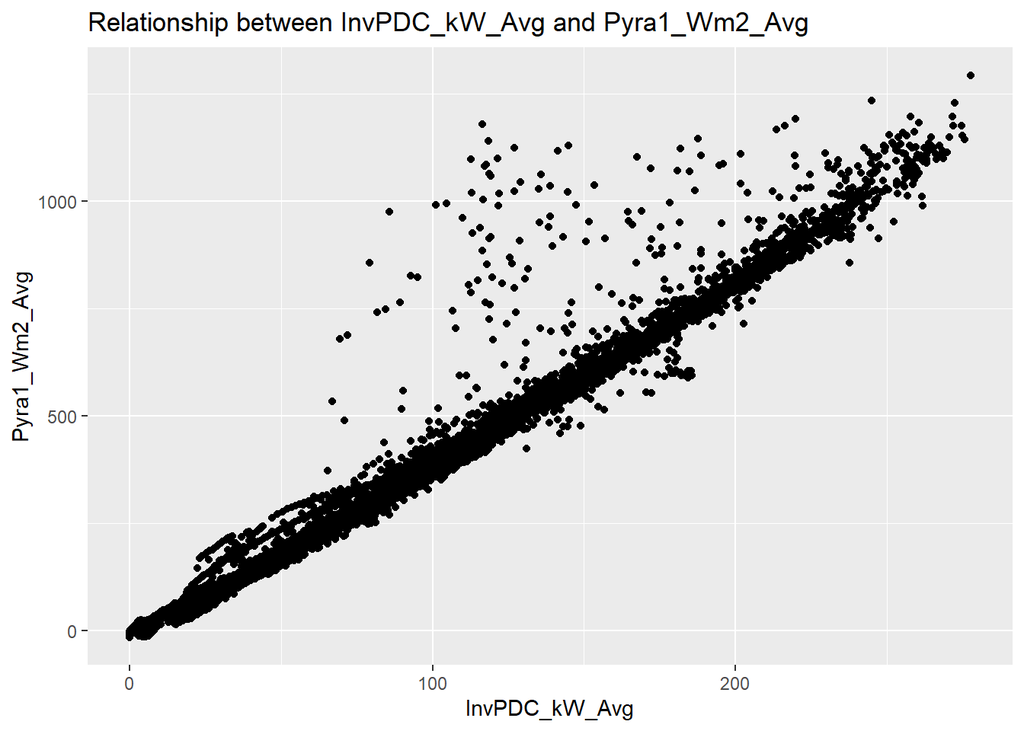

```r
ggplot(random_week_df, aes(x = InvPDC_kW_Avg, y = Pyra1_Wm2_Avg)) +
  geom_point() +
  labs(x = "InvPDC_kW_Avg", y = "Pyra1_Wm2_Avg") +
  ggtitle("Relationship between InvPDC_kW_Avg and Pyra1_Wm2_Avg")
```